# ReCell Project - Supervised Learning

#### Observations

1. It can be clearly observed that the phones with OS other than iOS, Andorid and Windows have lower used price for same number of days used.
2. Considering an year old phones (360 days), iOS phones have higher price ranges compared to Andorid phones for same number of days used.
3. For phones less than an year old, Some of the Android phones shows higher price than iOS phones.

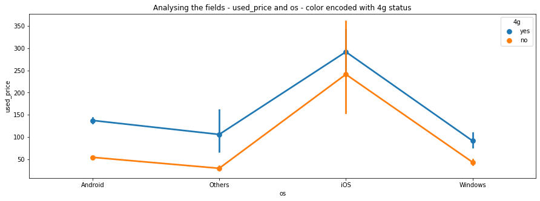

```python
# Set the figure size and title for the plot
plt.figure(figsize=(15,5))
plt.title('Analysing the fields - used_price and os - color encoded with 4g status')

# Show the pointplot with a legend - used_price and os - color encoded with 4g status
sns.pointplot(x="os", y="used_price", hue = '4g',  data=ReCell_Data)
plt.show()
```

#### Observations

1. It can be clearly observed that the phones equipped with 4G have higher price across all phone operating systems.
2. Since there are a lot of observations for Android phones, we can see a large price gap between phones with and without 4g is higher. But this price gap is smaller in iOS and Windows phones.

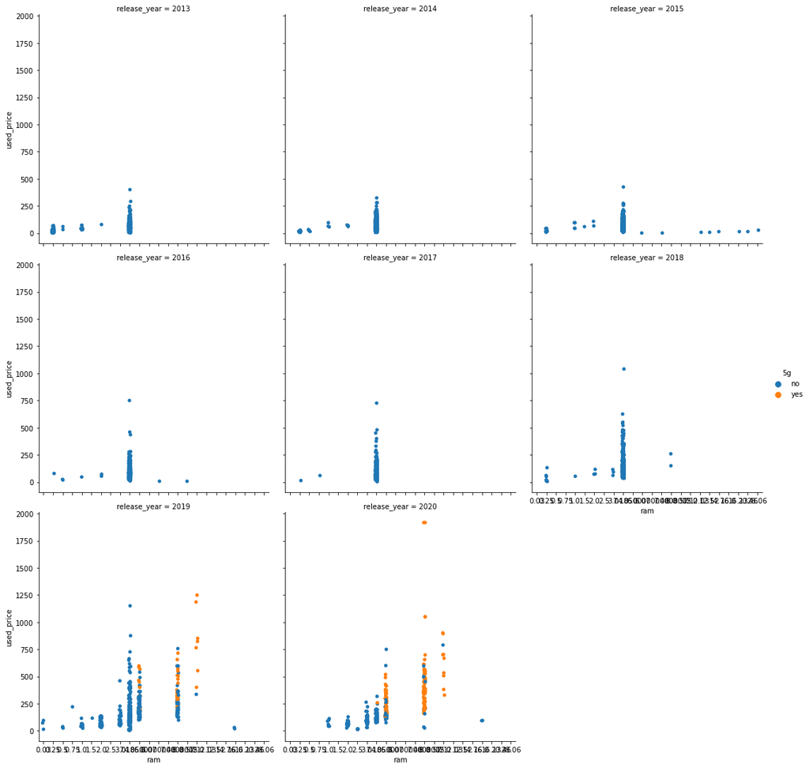

```python
# Show the Categorical Box plot with a legend - used price, ram, release year and 5g status.
sns.catplot(x="ram",
            y="used_price",
            hue="5g",
            col="release_year",
            data=ReCell_Data,
            kind="strip",
            col_wrap=3
           )
plt.show()
```

#### Observations

1. In 2013 and 2014, there were no phones greater than 4 GB ram, where as in 2019 and 2020, there are very few phones with ram less than 4 GB.
2. There is huge increase in phone prices from calender year 2013 to 2020.
3. The 5G started appearing the plot from Calender year 2019 and has become more prominent in 2020.

## **3. Questions on Exploratory Data Analysis(EDA)**

### Questions

#### 1. What does the distribution of used phone prices look like?

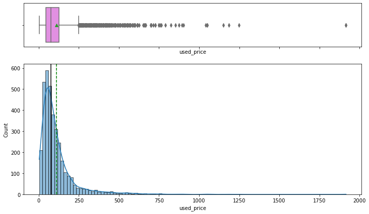

```python
# Display a histogram and boxplot with kde curve for the numeric column 'used_price'
histogram_boxplot(ReCell_Data,'used_price',kde=True,bins=100)
```

#### 2. What percentage of the used phone market is dominated by Android devices?

```python
# Get the number of rows with os = Android
No_of_Android_Devices = len(ReCell_Data[ReCell_Data['os']=='Android'])

# Get the total number of rows
Total_no_of_Devices = len(ReCell_Data['os'])

# Get the percentage of rows with os = Android
print(np.round((No_of_Android_Devices/Total_no_of_Devices)*100,2),'% of the used phone market is dominated by Android devices')
```

```
90.9 % of the used phone market is dominated by Android devices
```

#### Observations:

- 90.9 % of the used phone market is dominated by Android devices

#### 3. The amount of RAM is important for the smooth functioning of a phone. How does the amount of RAM vary with the brand?

```python
# Get the mean of ram grouped by brand_name and sort in descending order.
ReCell_Data.groupby(by='brand_name')['ram'].mean().sort_values(ascending=False).reset_index()
```

|  | brand_name | ram |
| --- | --- | --- |
| 0 | OnePlus | 6.363636 |
| 1 | Oppo | 4.961240 |
| 2 | Vivo | 4.756410 |
| 3 | Huawei | 4.641326 |
| 4 | Honor | 4.593220 |
| 5 | Xiaomi | 4.567164 |
| 6 | Google | 4.533333 |
| 7 | Meizu | 4.451613 |
| 8 | Nokia | 4.405083 |
| 9 | Realme | 4.195122 |
| 10 | Samsung | 4.159341 |
| 11 | Sony | 4.068182 |
| 12 | Asus | 4.047619 |
| 13 | ZTE | 4.023050 |
| 14 | Microsoft | 4.000000 |
| 15 | XOLO | 4.000000 |
| 16 | Apple | 4.000000 |
| 17 | Panasonic | 4.000000 |
| 18 | HTC | 4.000000 |
| 19 | Coolpad | 3.954545 |
| 20 | Motorola | 3.945455 |
| 21 | Gionee | 3.933036 |
| 22 | Acer | 3.901961 |
| 23 | LG | 3.893868 |
| 24 | Lenovo | 3.886628 |
| 25 | BlackBerry | 3.829545 |
| 26 | Others | 3.751041 |
| 27 | Micromax | 3.750000 |
| 28 | Spice | 3.750000 |
| 29 | Alcatel | 3.426000 |
| 30 | Karbonn | 3.375000 |
| 31 | Lava | 3.277778 |
| 32 | Infinix | 2.600000 |
| 33 | Celkon | 1.466216 |

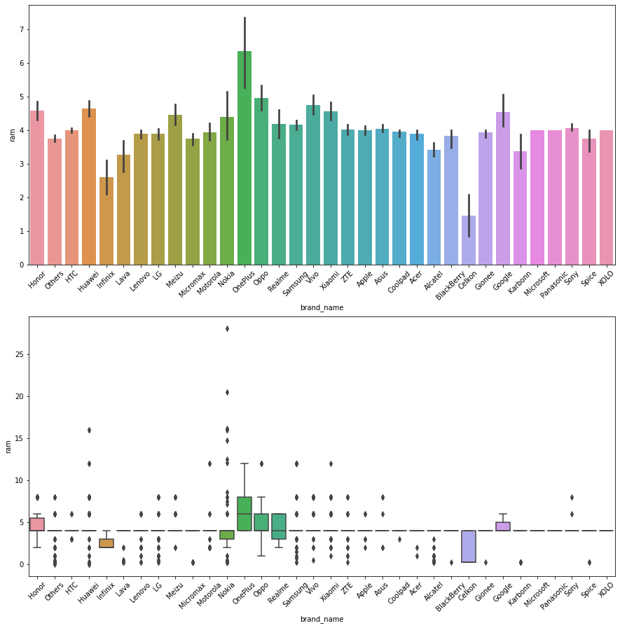

```python
# Set the figure size and title for the plot
plt.figure(figsize=(15, 15))
plt.title('Analysing the fields - ram and brand_name')

# Show the bar plot - ram and brand_name
plt.subplot(2, 1, 1)
sns.barplot(data=ReCell_Data, y="ram", x="brand_name")
plt.xticks(rotation=45)

# Show the box plot - ram and brand_name
plt.subplot(2, 1, 2)
sns.boxplot(data=ReCell_Data, y="ram", x="brand_name")
plt.xticks(rotation=45)

plt.show()
```

#### Observations:

1. OnePlus clearly dominates other brands when it comes to RAM.
2. OnePlus is followed by Oppo, Vivo, Huawei, Honor, Xiaomi and Google competing for second place.

#### 4. A large battery often increases a phone's weight, making it feel uncomfortable in the hands. How does the weight vary for phones offering large batteries (more than 4500 mAh)?

```python
# Create a dataframe with battery more than 4500 mAh
ReCell_Large_Battery_df = ReCell_Data[ReCell_Data['battery'] > 4500]

# Get the mean of battery grouped by brand_name and sort in descending order.
ReCell_Large_Battery_df.groupby(by='brand_name')['battery'].mean().sort_values(ascending=False).reset_index()
```

|  | brand_name | battery |
| --- | --- | --- |
| 0 | Google | 9240.000000 |
| 1 | Spice | 7600.000000 |
| 2 | Apple | 7087.342105 |
| 3 | Lenovo | 6700.689655 |
| 4 | HTC | 6700.000000 |
| 5 | Samsung | 6646.923077 |
| 6 | LG | 6150.000000 |
| 7 | Huawei | 6021.081081 |
| 8 | Sony | 6000.000000 |
| 9 | Others | 5854.878049 |
| 10 | Acer | 5488.571429 |
| 11 | Asus | 5364.545455 |
| 12 | Gionee | 5361.000000 |
| 13 | Honor | 5342.857143 |
| 14 | Infinix | 5333.333333 |
| 15 | Nokia | 5300.000000 |
| 16 | Xiaomi | 5269.677419 |
| 17 | ZTE | 5020.000000 |
| 18 | Motorola | 5000.000000 |
| 19 | Oppo | 5000.000000 |
| 20 | Panasonic | 5000.000000 |
| 21 | Realme | 5000.000000 |
| 22 | Vivo | 5000.000000 |
| 23 | Micromax | 4800.000000 |
| 24 | Alcatel | 4600.000000 |

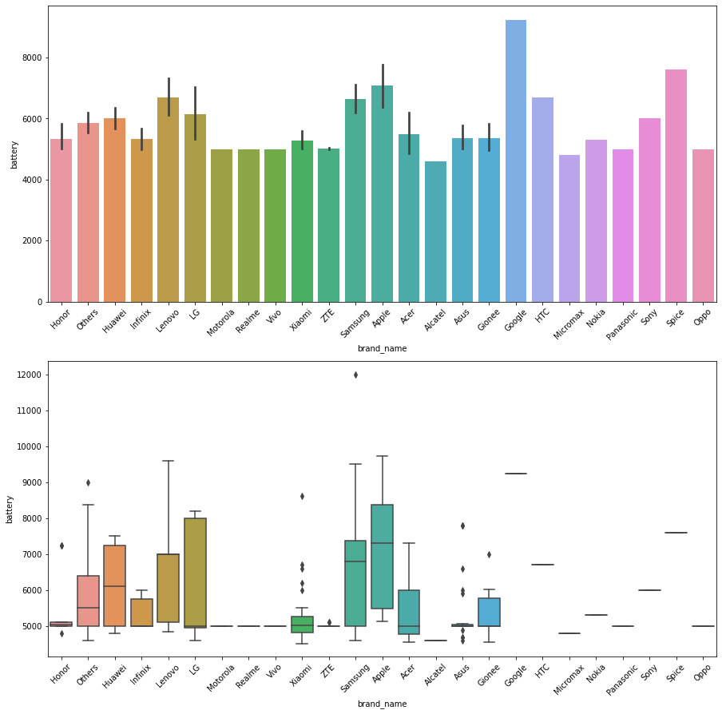

```python
# Set the figure size and title for the plot
plt.figure(figsize=(15, 15))
plt.title('Analysing the fields - battery and brand_name')

# Show the bar plot - battery and brand_name
plt.subplot(2, 1, 1)
sns.barplot(data=ReCell_Large_Battery_df, y="battery", x="brand_name")
plt.xticks(rotation=45)

# Show the box plot - battery and brand_name
plt.subplot(2, 1, 2)
sns.boxplot(data=ReCell_Large_Battery_df, y="battery", x="brand_name")
plt.xticks(rotation=45)

plt.show()
```

#### Observations:

1. Google clearly dominates other brands when it comes to battery capacity.
2. Google is followed by Spice and Apple competing for second place.
3. It can also be noticed that Google and Spice have only one observation with battery more than 4500 mAh.

#### 5. Bigger screens are desirable for entertainment purposes as they offer a better viewing experience. How many phones are available across different brands with a screen size larger than 6 inches?

```python
# Create a dataframe with screen size larger than 6 inches.
ReCell_Large_Screen_df = ReCell_Data[ReCell_Data['screen_size'] > 6]

# Get the mean of screen_size grouped by brand_name and sort in descending order.
ReCell_Large_Screen_df.groupby(by='brand_name')['screen_size'].mean().sort_values(ascending=False).reset_index()
```

|  | brand_name | screen_size |
| --- | --- | --- |
| 0 | OnePlus | 20.810909 |
| 1 | Honor | 19.046102 |
| 2 | Vivo | 19.031795 |
| 3 | Xiaomi | 18.995522 |
| 4 | Infinix | 18.478000 |
| 5 | Apple | 17.761509 |
| 6 | Realme | 17.655610 |
| 7 | Huawei | 17.498988 |
| 8 | Lenovo | 16.110000 |
| 9 | Oppo | 15.576977 |
| 10 | Asus | 15.506270 |
| 11 | Acer | 15.245490 |
| 12 | Meizu | 15.221129 |
| 13 | Samsung | 15.177368 |
| 14 | Google | 15.060000 |
| 15 | Nokia | 14.408953 |
| 16 | Others | 14.326914 |
| 17 | Sony | 14.178372 |
| 18 | Motorola | 14.152091 |
| 19 | LG | 14.088137 |
| 20 | ZTE | 14.061929 |
| 21 | Coolpad | 14.040000 |
| 22 | Gionee | 13.620536 |
| 23 | Alcatel | 13.600339 |
| 24 | Microsoft | 13.010000 |
| 25 | Panasonic | 12.996170 |
| 26 | HTC | 12.966364 |
| 27 | XOLO | 12.482041 |
| 28 | Lava | 12.465278 |
| 29 | BlackBerry | 12.410909 |
| 30 | Micromax | 12.403190 |
| 31 | Spice | 11.746000 |
| 32 | Karbonn | 11.683667 |
| 33 | Celkon | 10.480968 |

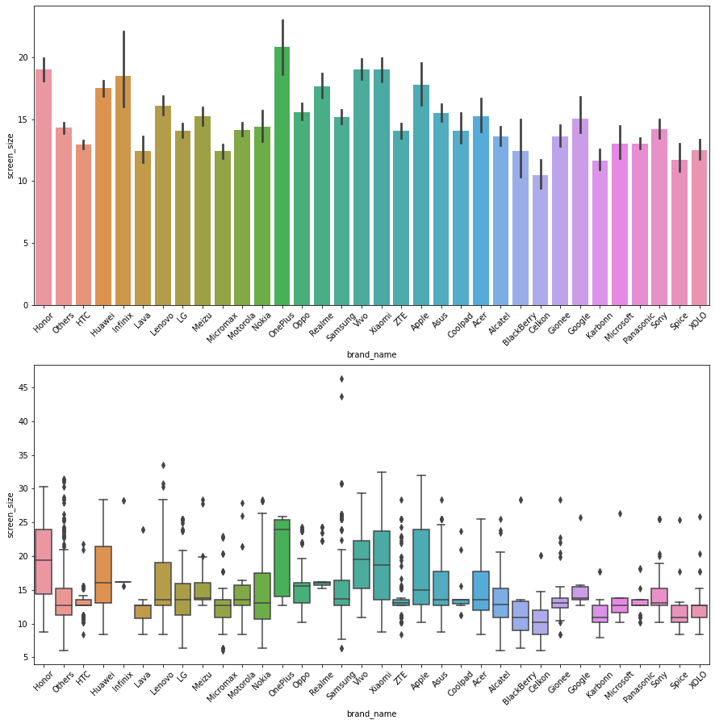

```python
# Set the figure size and title for the plot
plt.figure(figsize=(15, 15))
plt.title('Analysing the fields - screen_size and brand_name')

# Show the bar plot - screen_size and brand_name
plt.subplot(2, 1, 1)
sns.barplot(data=ReCell_Large_Screen_df, y="screen_size", x="brand_name")
plt.xticks(rotation=45)

# Show the box plot - screen_size and brand_name
plt.subplot(2, 1, 2)
sns.boxplot(data=ReCell_Large_Screen_df, y="screen_size", x="brand_name")
plt.xticks(rotation=45)

plt.show()
```

#### Observations:

1. OnePlus clearly dominates other brands when it comes to screen size.
2. OnePlus is followed by Honor, Vivo and Xiaomi competing for second place.

#### 6. Budget phones nowadays offer great selfie cameras, allowing us to capture our favorite moments with loved ones. What is the distribution of budget phones offering greater than 8MP selfie cameras across brands?

```python
# Create a dataframe for phones offering greater than 8MP selfie cameras
ReCell_HR_SelfieCam_df = ReCell_Data[ReCell_Data['selfie_camera_mp'] > 8]

# Get the mean of selfie_camera_mp grouped by brand_name and sort in descending order.
ReCell_HR_SelfieCam_df.groupby(by='brand_name')['selfie_camera_mp'].mean().sort_values(ascending=False).reset_index()
```

|  | brand_name | selfie_camera_mp |
| --- | --- | --- |
| 0 | Google | 115.000000 |
| 1 | Oppo | 22.120000 |
| 2 | Honor | 20.802326 |
| 3 | Huawei | 20.670330 |
| 4 | Lenovo | 20.142857 |
| 5 | Xiaomi | 19.338462 |
| 6 | Nokia | 18.900000 |
| 7 | Motorola | 18.692308 |
| 8 | Vivo | 18.564103 |
| 9 | Meizu | 18.541667 |
| 10 | Samsung | 18.183333 |
| 11 | Realme | 17.166667 |
| 12 | Others | 16.450000 |
| 13 | Gionee | 16.250000 |
| 14 | BlackBerry | 16.000000 |
| 15 | Infinix | 16.000000 |
| 16 | OnePlus | 16.000000 |
| 17 | LG | 15.937500 |
| 18 | ZTE | 15.450000 |
| 19 | Asus | 15.333333 |
| 20 | Panasonic | 14.500000 |
| 21 | HTC | 14.100000 |
| 22 | Coolpad | 14.000000 |
| 23 | Sony | 13.428571 |
| 24 | Micromax | 13.000000 |
| 25 | Acer | 13.000000 |

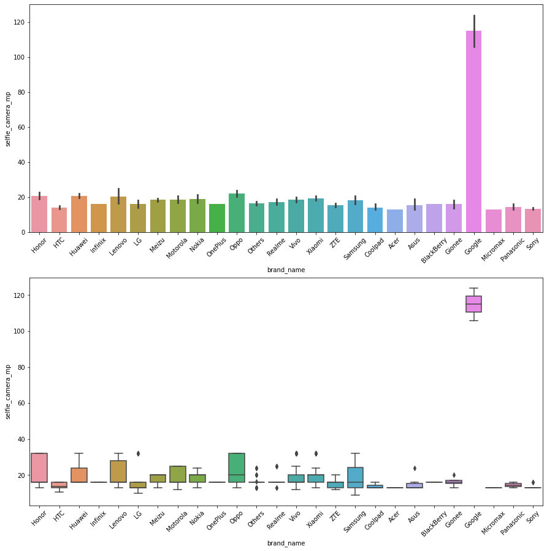

```python
# Set the figure size and title for the plot
plt.figure(figsize=(15, 15))
plt.title('Analysing the fields - selfie_camera_mp and brand_name')

# Show the bar plot - selfie_camera_mp and brand_name
plt.subplot(2, 1, 1)
sns.barplot(data=ReCell_HR_SelfieCam_df, y="selfie_camera_mp", x="brand_name")
plt.xticks(rotation=45)

# Show the box plot - selfie_camera_mp and brand_name
plt.subplot(2, 1, 2)
sns.boxplot(data=ReCell_HR_SelfieCam_df, y="selfie_camera_mp", x="brand_name")
plt.xticks(rotation=45)

plt.show()
```

#### Observations:

1. Google clearly dominates other brands when it comes to selfie camera mega pixels.
2. Google is followed by Oppo, Honor, Huawei and Lenovo competing for second place.

#### 7. Which attributes are highly correlated with the used phone price?

```python
# Get the correlation of used_price column to other columns.
ReCell_Corr_df = ReCell_Data.corr()['used_price'].reset_index()

# Rename the used_price column.
ReCell_Corr_df.rename(columns={'used_price':'corr_with_used_price'},inplace=True)

# Sort the column corr_with_used_price in descending order.
ReCell_Corr_df.sort_values(by='corr_with_used_price',ascending=True)
```

|  | index | corr_with_used_price |
| --- | --- | --- |
| 8 | days_used | -0.470760 |
| 6 | weight | 0.172123 |
| 1 | main_camera_mp | 0.351891 |
| 5 | battery | 0.363600 |
| 0 | screen_size | 0.385928 |
| 3 | int_memory | 0.405508 |
| 7 | release_year | 0.456764 |
| 4 | ram | 0.466508 |
| 2 | selfie_camera_mp | 0.488368 |
| 9 | new_price | 0.926087 |
| 10 | used_price | 1.000000 |

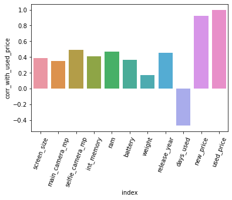

```python
# Show the bar plot - columns and their correlation with used_price
sns.barplot(data=ReCell_Corr_df,x='index',y='corr_with_used_price')
plt.xticks(rotation=70)
plt.show()
```

#### Observations:

1. Used_price is highly positively corelated with new_price (0.93), which makes sense as the new price factors in for determining the used price of the phone.
2. Used_price is positively corelated with release_year (0.46). In other words, newer the phone, higher the price.
3. Used_price is positively corelated with ram (0.47), price increases as RAM memory is increased.
4. Used_price is positively corelated with selfie_camera_mp (0.49). In other words, higher the megapixels in selfie camera, higher the price.
5. Used_price is positively corelated with int_memory (0.41), price increases as internal memory is increased.
6. Used_price is negatively corelated with days_used (-0.47). The more the phone is used, the value goes down.

#### Let's convert the *object* type columns to *category* type

```python
# convert the object type columns to category type for brand_name, os, 4g and 5g.
ReCell_Data['brand_name'] = ReCell_Data['brand_name'].astype("category")
ReCell_Data['os'] = ReCell_Data['os'].astype("category")
ReCell_Data['4g'] = ReCell_Data['4g'].astype("category")
ReCell_Data['5g'] = ReCell_Data['5g'].astype("category")

# use info() method to print a concise summary of the pandas DataFrame
ReCell_Data.info()
```

```
<class 'pandas.core.frame.DataFrame'>
RangeIndex: 3571 entries, 0 to 3570
Data columns (total 15 columns):
 #   Column            Non-Null Count  Dtype
---  ------            --------------  -----
 0   brand_name        3571 non-null   category
 1   os                3571 non-null   category
 2   screen_size       3571 non-null   float64
 3   4g                3571 non-null   category
 4   5g                3571 non-null   category
 5   main_camera_mp    3571 non-null   float64
 6   selfie_camera_mp  3571 non-null   float64
 7   int_memory        3571 non-null   float64
 8   ram               3571 non-null   float64
 9   battery           3571 non-null   float64
 10  weight            3571 non-null   float64
 11  release_year      3571 non-null   int64
 12  days_used         3571 non-null   int64
 13  new_price         3571 non-null   float64
 14  used_price        3571 non-null   float64
dtypes: category(4), float64(9), int64(2)
memory usage: 322.8 KB
```

#### Observations:

- 4 columns brand_name, os, 4g and 5g are converted to category.

### Data Preprocessing (cont.)

#### Log Transformation

- The used price distribution is skewed and could perform better if log transformed.

```python
# Apply log transformation
#ReCell_Data['used_price'] = np.log(ReCell_Data['used_price'])
```

```python
# Get the sample of data for random_state = 1
#ReCell_Data.sample(n=10, random_state=1)
```

#### Observations:

- After doing the models with and without Log transformation, I decided to **not** do Log transformation as the model without Log transformation was giving higher accuracy.

#### Outlier Treatment

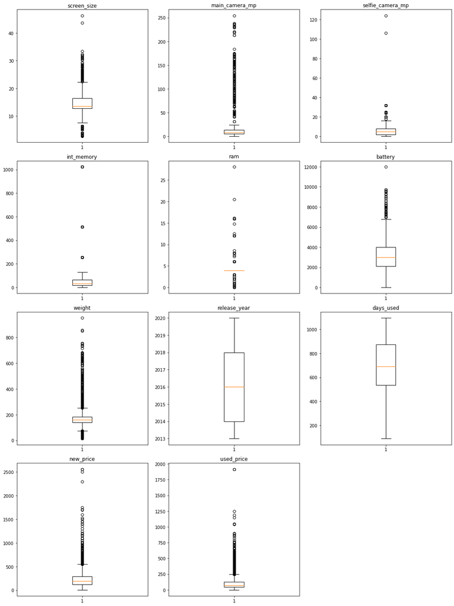

```python
# identify the numeric columns for finding outliers.
numeric_columns = ReCell_Data.select_dtypes(include=np.number).columns.tolist()

# let's plot the boxplots of all numeric columns to check for outliers
plt.figure(figsize=(15, 20))

for i, variable in enumerate(numeric_columns):
    plt.subplot(4, 3, i + 1)
    plt.boxplot(ReCell_Data[variable], whis=1.5)
    plt.tight_layout()
    plt.title(variable)

plt.show()
```

#### Observations:

- There are outliers in every numeric column except release year and days used.

#### Treating outliers in the data by flooring and capping.

```python
# function to treat outliers for one column.
def treat_outliers(df, col):
    """
    treats outliers in a variable
    col: str, name of the numerical variable
    df: dataframe
    col: name of the column
    """
    Q1 = df[col].quantile(0.25)  # 25th quantile
    Q3 = df[col].quantile(0.75)  # 75th quantile
    IQR = Q3 - Q1
    Lower_Whisker = Q1 - 1.5 * IQR
    Upper_Whisker = Q3 + 1.5 * IQR

    # all the values smaller than Lower_Whisker will be assigned the value of Lower_Whisker
    # all the values greater than Upper_Whisker will be assigned the value of Upper_Whisker
    df[col] = np.clip(df[col], Lower_Whisker, Upper_Whisker)

    return df

# function to treat outliers for all columns in one go.
def treat_outliers_all(df, col_list):
    """
    treat outlier in all numerical variables
    col_list: list of numerical variables
    df: data frame
    """
    for c in col_list:
        df = treat_outliers(df, c)

    return df
```

```python
# Applying the function to treat outliers for all numeric columns.
ReCell_Data = treat_outliers_all(ReCell_Data,numeric_columns)
```

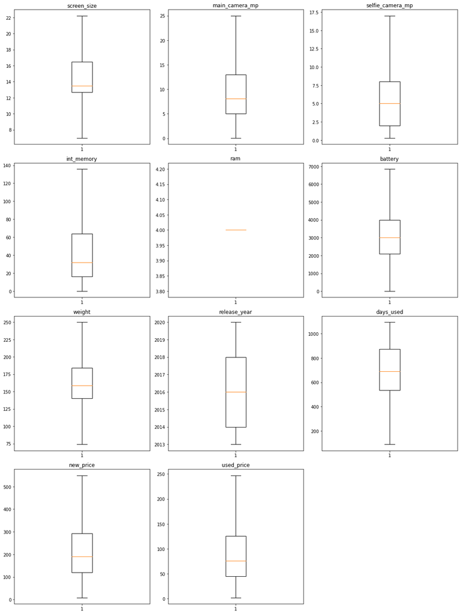

```python
# let's plot the boxplots of all numeric columns to check for outliers
plt.figure(figsize=(15, 20))

for i, variable in enumerate(numeric_columns):
    plt.subplot(4, 3, i + 1)
    plt.boxplot(ReCell_Data[variable], whis=1.5)
    plt.tight_layout()
    plt.title(variable)

plt.show()
```

#### Observations:

- All the outliers are fixed.
- Good to build the liner regression model

```python
# Get the sample of data for random_state = 1
ReCell_Data.sample(n=10, random_state=1)
```

|  | brand_name | os | screen_size | 4g | 5g | main_camera_mp | selfie_camera_mp | int_memory | ram | battery | weight | release_year | days_used | new_price | used_price |
| --- | --- | --- | --- | --- | --- | --- | --- | --- | --- | --- | --- | --- | --- | --- | --- |
| 2501 | Samsung | Android | 13.490 | yes | no | 13.0 | 13.0 | 32.0 | 4.0 | 3600.0 | 181.0 | 2017 | 683 | 198.6800 | 79.4700 |
| 2782 | Sony | Android | 13.810 | yes | no | 25.0 | 8.0 | 32.0 | 4.0 | 3300.0 | 156.0 | 2019 | 195 | 198.1500 | 149.1000 |
| 605 | Others | Android | 12.700 | yes | no | 8.0 | 5.0 | 16.0 | 4.0 | 2400.0 | 137.0 | 2015 | 1048 | 161.4700 | 48.3900 |
| 2923 | Vivo | Android | 19.370 | yes | no | 13.0 | 16.0 | 64.0 | 4.0 | 3260.0 | 149.3 | 2019 | 375 | 211.8800 | 138.3100 |
| 941 | Others | Others | 6.985 | no | no | 0.3 | 0.3 | 32.0 | 4.0 | 820.0 | 90.0 | 2013 | 883 | 29.8100 | 8.9200 |
| 1833 | LG | Android | 13.490 | no | no | 8.0 | 1.3 | 32.0 | 4.0 | 3140.0 | 161.0 | 2013 | 670 | 240.5400 | 96.1800 |
| 671 | Apple | iOS | 14.920 | yes | no | 12.0 | 7.0 | 64.0 | 4.0 | 5493.0 | 74.0 | 2018 | 403 | 549.6425 | 247.1925 |
| 1796 | LG | Android | 17.780 | yes | no | 5.0 | 0.3 | 16.0 | 4.0 | 4000.0 | 250.0 | 2014 | 708 | 189.3000 | 75.9400 |
| 757 | Asus | Android | 13.490 | yes | no | 13.0 | 8.0 | 32.0 | 4.0 | 5000.0 | 181.0 | 2017 | 612 | 270.5000 | 108.1300 |
| 3528 | Realme | Android | 15.720 | yes | no | 25.0 | 16.0 | 64.0 | 4.0 | 4035.0 | 184.0 | 2019 | 433 | 159.8850 | 80.0000 |

## **4. Building a Linear Regression model**

Build a Linear Regression model using the train data and then check it's performance.

```python
# defining X and y variables
# Columns 'ram' is removed as it only contain the value 4 GB after outliers are treated.
X = ReCell_Data.drop(['used_price','ram'], axis=1)
y = ReCell_Data['used_price']
```

```python
# Get sample of X
X.sample(n=10, random_state=1)
```

|  | brand_name | os | screen_size | 4g | 5g | main_camera_mp | selfie_camera_mp | int_memory | battery | weight | release_year | days_used | new_price |
| --- | --- | --- | --- | --- | --- | --- | --- | --- | --- | --- | --- | --- | --- |
| 2501 | Samsung | Android | 13.490 | yes | no | 13.0 | 13.0 | 32.0 | 3600.0 | 181.0 | 2017 | 683 | 198.6800 |
| 2782 | Sony | Android | 13.810 | yes | no | 25.0 | 8.0 | 32.0 | 3300.0 | 156.0 | 2019 | 195 | 198.1500 |
| 605 | Others | Android | 12.700 | yes | no | 8.0 | 5.0 | 16.0 | 2400.0 | 137.0 | 2015 | 1048 | 161.4700 |
| 2923 | Vivo | Android | 19.370 | yes | no | 13.0 | 16.0 | 64.0 | 3260.0 | 149.3 | 2019 | 375 | 211.8800 |
| 941 | Others | Others | 6.985 | no | no | 0.3 | 0.3 | 32.0 | 820.0 | 90.0 | 2013 | 883 | 29.8100 |
| 1833 | LG | Android | 13.490 | no | no | 8.0 | 1.3 | 32.0 | 3140.0 | 161.0 | 2013 | 670 | 240.5400 |
| 671 | Apple | iOS | 14.920 | yes | no | 12.0 | 7.0 | 64.0 | 5493.0 | 74.0 | 2018 | 403 | 549.6425 |
| 1796 | LG | Android | 17.780 | yes | no | 5.0 | 0.3 | 16.0 | 4000.0 | 250.0 | 2014 | 708 | 189.3000 |
| 757 | Asus | Android | 13.490 | yes | no | 13.0 | 8.0 | 32.0 | 5000.0 | 181.0 | 2017 | 612 | 270.5000 |
| 3528 | Realme | Android | 15.720 | yes | no | 25.0 | 16.0 | 64.0 | 4035.0 | 184.0 | 2019 | 433 | 159.8850 |

```python
# Get sample of y
y.sample(n=10, random_state=1)
```

```
2501     79.4700
2782    149.1000
605      48.3900
2923    138.3100
941       8.9200
1833     96.1800
671     247.1925
1796     75.9400
757     108.1300
3528     80.0000
Name: used_price, dtype: float64
```

```python
# Convert categorical variable into dummy/indicator variables - one hot encoding
X = pd.get_dummies(
    X,
    columns=X.select_dtypes(include='category').columns.tolist(),
    drop_first=True,
)
X.head()
```

|  | screen_size | main_camera_mp | selfie_camera_mp | int_memory | battery | weight | release_year | days_used | new_price | brand_name_Alcatel | brand_name_Apple | brand_name_Asus | brand_name_BlackBerry | brand_name_Celkon | brand_name_Coolpad | brand_name_Gionee | brand_name_Google | brand_name_HTC | brand_name_Honor | brand_name_Huawei | brand_name_Infinix | brand_name_Karbonn | brand_name_LG | brand_name_Lava | brand_name_Lenovo | brand_name_Meizu | brand_name_Micromax | brand_name_Microsoft | brand_name_Motorola | … |
| --- | --- | --- | --- | --- | --- | --- | --- | --- | --- | --- | --- | --- | --- | --- | --- | --- | --- | --- | --- | --- | --- | --- | --- | --- | --- | --- | --- | --- | --- | --- |
| 0 | 22.225 | 13.0 | 5.0 | 64.0 | 3020.0 | 146.0 | 2020 | 127 | 111.62 | 0 | 0 | 0 | 0 | 0 | 0 | 0 | 0 | 0 | 1 | 0 | 0 | 0 | 0 | 0 | 0 | 0 | 0 | 0 | 0 | … |
| 1 | 22.225 | 13.0 | 16.0 | 128.0 | 4300.0 | 213.0 | 2020 | 325 | 249.39 | 0 | 0 | 0 | 0 | 0 | 0 | 0 | 0 | 0 | 1 | 0 | 0 | 0 | 0 | 0 | 0 | 0 | 0 | 0 | 0 | … |
| 2 | 22.225 | 13.0 | 8.0 | 128.0 | 4200.0 | 213.0 | 2020 | 162 | 359.47 | 0 | 0 | 0 | 0 | 0 | 0 | 0 | 0 | 0 | 1 | 0 | 0 | 0 | 0 | 0 | 0 | 0 | 0 | 0 | 0 | … |
| 3 | 22.225 | 13.0 | 8.0 | 64.0 | 6850.0 | 250.0 | 2020 | 345 | 278.93 | 0 | 0 | 0 | 0 | 0 | 0 | 0 | 0 | 0 | 1 | 0 | 0 | 0 | 0 | 0 | 0 | 0 | 0 | 0 | 0 | … |
| 4 | 15.720 | 13.0 | 8.0 | 64.0 | 5000.0 | 185.0 | 2020 | 293 | 140.87 | 0 | 0 | 0 | 0 | 0 | 0 | 0 | 0 | 0 | 1 | 0 | 0 | 0 | 0 | 0 | 0 | 0 | 0 | 0 | 0 | … |

```python
# splitting the data in 70:30 ratio for train to test data
x_train, x_test, y_train, y_test = train_test_split(
    X, y, test_size=0.3, random_state=1
)

print("Number of rows in train data =", x_train.shape[0])
print("Number of rows in test data =", x_test.shape[0])
```

```
Number of rows in train data = 2499
Number of rows in test data = 1072
```

```python
# fitting the model on the train data (70% of the whole data)
from sklearn.linear_model import LinearRegression

ReCell_Sklearn_Linear_Model = LinearRegression()
ReCell_Sklearn_Linear_Model.fit(x_train, y_train)
```

```
LinearRegression()
```

#### Let's check the coefficients and intercept of the model.

```python
ReCell_Sklearn_Coef_df = pd.DataFrame(
    np.append(ReCell_Sklearn_Linear_Model.coef_, ReCell_Sklearn_Linear_Model.intercept_),
    index=x_train.columns.tolist() + ["Intercept"],
    columns=["Coefficients"],
)

ReCell_Sklearn_Coef_df.round(5)
```

|  | Coefficients |
| --- | --- |
| screen_size | 0.44039 |
| main_camera_mp | -0.10597 |
| selfie_camera_mp | 0.75213 |
| int_memory | 0.11144 |
| battery | -0.00025 |
| weight | -0.00911 |
| release_year | -0.31179 |
| days_used | -0.08556 |
| new_price | 0.37594 |
| brand_name_Alcatel | 2.10489 |
| brand_name_Apple | -15.10518 |
| brand_name_Asus | 2.23130 |
| brand_name_BlackBerry | 11.27401 |
| brand_name_Celkon | -3.79878 |
| brand_name_Coolpad | 2.40509 |
| brand_name_Gionee | -3.93301 |
| brand_name_Google | 16.31347 |
| brand_name_HTC | 0.64958 |
| brand_name_Honor | -1.47132 |
| brand_name_Huawei | 0.07329 |
| brand_name_Infinix | -13.77190 |
| brand_name_Karbonn | -0.96962 |
| brand_name_LG | 3.21297 |
| brand_name_Lava | 0.92081 |
| brand_name_Lenovo | -2.16537 |
| brand_name_Meizu | -0.07427 |
| brand_name_Micromax | 3.75132 |
| brand_name_Microsoft | 2.12892 |
| brand_name_Motorola | -2.01484 |
| brand_name_Nokia | -6.74060 |
| brand_name_OnePlus | -13.16606 |
| brand_name_Oppo | -1.21108 |
| brand_name_Others | 0.95839 |
| brand_name_Panasonic | -1.46712 |
| brand_name_Realme | -0.77261 |
| brand_name_Samsung | 1.57797 |
| brand_name_Sony | 3.13358 |
| brand_name_Spice | 5.38308 |
| brand_name_Vivo | 0.88454 |
| brand_name_XOLO | 2.96160 |
| brand_name_Xiaomi | -1.69757 |
| brand_name_ZTE | 0.54571 |
| os_Others | -3.22143 |
| os_Windows | 0.50202 |
| os_iOS | 26.82794 |
| 4g_yes | -2.62239 |
| 5g_yes | 4.19266 |
| Intercept | 687.14488 |

#### Let's check the performance of the model using different metrics.

- using metric functions defined in sklearn for RMSE, MAE, and $R^2$.

```python
# function to compute adjusted R-squared
def adj_r2_score(predictors, targets, predictions):
    r2 = r2_score(targets, predictions)
    n = predictors.shape[0]
    k = predictors.shape[1]
    return 1 - ((1 - r2) * (n - 1) / (n - k - 1))


# function to compute MAPE
def mape_score(targets, predictions):
    return np.mean(np.abs(targets - predictions) / targets) * 100


# function to compute different metrics to check performance of a regression model
def model_performance_regression(model, predictors, target):
    """
    Function to compute different metrics to check regression model performance

    model: regressor
    predictors: independent variables
    target: dependent variable
    """

    # predicting using the independent variables
    pred = model.predict(predictors)

    r2 = r2_score(target, pred)  # to compute R-squared
    adjr2 = adj_r2_score(predictors, target, pred)  # to compute adjusted R-squared
    rmse = np.sqrt(mean_squared_error(target, pred))  # to compute RMSE
    mae = mean_absolute_error(target, pred)  # to compute MAE
    mape = mape_score(target, pred)  # to compute MAPE

    # creating a dataframe of metrics
    df_perf = pd.DataFrame(
        {
            "RMSE": rmse,
            "MAE": mae,
            "R-squared": r2,
            "Adj. R-squared": adjr2,
            "MAPE": mape,
        },
        index=[0],
    )

    return df_perf
```

```python
# checking model performance on train set (seen 70% data)
print("Training Performance\n")
ReCell_Sklearn_train_perf = model_performance_regression(
    ReCell_Sklearn_Linear_Model, x_train, y_train
)
ReCell_Sklearn_train_perf
```

```
Training Performance
```

|  | RMSE | MAE | R-squared | Adj. R-squared | MAPE |
| --- | --- | --- | --- | --- | --- |
| 0 | 13.749809 | 10.186292 | 0.956775 | 0.955946 | 18.037741 |

```python
# checking model performance on test set (seen 30% data)
print("Test Performance\n")
ReCell_Sklearn_test_perf = model_performance_regression(
    ReCell_Sklearn_Linear_Model, x_test, y_test
)
ReCell_Sklearn_test_perf
```

```
Test Performance
```

|  | RMSE | MAE | R-squared | Adj. R-squared | MAPE |
| --- | --- | --- | --- | --- | --- |
| 0 | 14.539187 | 10.530216 | 0.951679 | 0.949461 | 18.57421 |

## **5. Linear Regression using statsmodels**

- Build a linear regression model using statsmodels.

```python
# unlike sklearn, statsmodels does not add a constant to the data on its own
# we have to add the constant manually
x_train1 = sm.add_constant(x_train)
# adding constant to the test data
x_test1 = sm.add_constant(x_test)

olsmod0 = sm.OLS(y_train, x_train1).fit()
print(olsmod0.summary())
```

```
                            OLS Regression Results
==============================================================================
Dep. Variable:             used_price   R-squared:                       0.957
Model:                            OLS   Adj. R-squared:                  0.956
Method:                 Least Squares   F-statistic:                     1154.
Date:                Sat, 23 Oct 2021   Prob (F-statistic):               0.00
Time:                        03:16:17   Log-Likelihood:                -10096.
No. Observations:                2499   AIC:                         2.029e+04
Df Residuals:                    2451   BIC:                         2.057e+04
Df Model:                          47
Covariance Type:            nonrobust
=========================================================================================
                            coef    std err          t      P>|t|      [0.025      0.975]
-----------------------------------------------------------------------------------------
const                   687.1449    551.404      1.246      0.213    -394.122    1768.412
screen_size               0.4404      0.127      3.471      0.001       0.192       0.689
main_camera_mp           -0.1060      0.077     -1.383      0.167      -0.256       0.044
selfie_camera_mp          0.7521      0.101      7.425      0.000       0.553       0.951
int_memory                0.1114      0.011     10.339      0.000       0.090       0.133
battery                  -0.0002      0.000     -0.606      0.544      -0.001       0.001
weight                   -0.0091      0.012     -0.773      0.440      -0.032       0.014
release_year             -0.3118      0.274     -1.140      0.254      -0.848       0.225
days_used                -0.0856      0.002    -47.781      0.000      -0.089      -0.082
new_price                 0.3759      0.003    114.217      0.000       0.369       0.382
brand_name_Alcatel        2.1049      2.869      0.734      0.463      -3.522       7.732
brand_name_Apple        -15.1052     10.347     -1.460      0.144     -35.395       5.185
brand_name_Asus           2.2313      2.793      0.799      0.424      -3.245       7.708
brand_name_BlackBerry    11.2740      4.314      2.614      0.009       2.815      19.733
brand_name_Celkon        -3.7988      3.864     -0.983      0.326     -11.375       3.778
brand_name_Coolpad        2.4051      4.561      0.527      0.598      -6.539      11.349
brand_name_Gionee        -3.9330      3.236     -1.215      0.224     -10.279       2.413
brand_name_Google        16.3135      5.253      3.105      0.002       6.012      26.615
brand_name_HTC            0.6496      2.858      0.227      0.820      -4.954       6.253
brand_name_Honor         -1.4713      2.908     -0.506      0.613      -7.175       4.232
brand_name_Huawei         0.0733      2.614      0.028      0.978      -5.052       5.199
brand_name_Infinix      -13.7719      5.627     -2.447      0.014     -24.807      -2.737
brand_name_Karbonn       -0.9696      3.763     -0.258      0.797      -8.350       6.410
brand_name_LG             3.2130      2.651      1.212      0.226      -1.986       8.412
brand_name_Lava           0.9208      3.708      0.248      0.804      -6.349       8.191
brand_name_Lenovo        -2.1654      2.691     -0.805      0.421      -7.442       3.111
```

[output cut: 18 more lines]

```
os_Windows                0.5020      2.668      0.188      0.851      -4.729       5.733
os_iOS                   26.8279     10.259      2.615      0.009       6.710      46.946
4g_yes                   -2.6224      0.893     -2.936      0.003      -4.374      -0.871
5g_yes                    4.1927      1.656      2.532      0.011       0.946       7.439
==============================================================================
Omnibus:                      243.548   Durbin-Watson:                   1.986
Prob(Omnibus):                  0.000   Jarque-Bera (JB):              527.047
Skew:                           0.605   Prob(JB):                    3.57e-115
Kurtosis:                       4.897   Cond. No.                     7.71e+06
==============================================================================

Notes:
[1] Standard Errors assume that the covariance matrix of the errors is correctly specified.
[2] The condition number is large, 7.71e+06. This might indicate that there are
strong multicollinearity or other numerical problems.
```

#### Observations

- Negative values of the coefficient show that *used price* decreases with the increase of corresponding attribute value.
- Positive values of the coefficient show that *used price* increases with the increase of corresponding attribute value.
- p-value of a variable indicates if the variable is significant or not. If we consider the significance level to be 0.05 (5%), then any variable with a p-value less than 0.05 would be considered significant.
- But these variables might contain multicollinearity, which will affect the p-values.
- So, we need to deal with multicollinearity and check the other assumptions of linear regression first, and then look at the p-values.

## **6. Checking Linear Regression Assumptions**

- In order to make statistical inferences from a linear regression model, it is important to ensure that the assumptions of linear regression are satisfied.

Checking the following Linear Regression assumptions:

1. **No Multicollinearity**
2. **Linearity of variables**
3. **Independence of error terms**
4. **Normality of error terms**
5. **No Heteroscedasticity**

### TEST FOR MULTICOLLINEARITY

- Multicollinearity occurs when predictor variables in a regression model are correlated. This correlation is a problem because predictor variables should be independent. If the correlation between variables is high, it can cause problems when we fit the model and interpret the results. When we have multicollinearity in the linear model, the coefficients that the model suggests are unreliable.
- There are different ways of detecting (or testing) multicollinearity. One such way is by using the Variance Inflation Factor, or VIF.
- **Variance Inflation Factor (VIF)**: Variance inflation factors measure the inflation in the variances of the regression parameter estimates due to collinearities that exist among the predictors. It is a measure of how much the variance of the estimated regression coefficient $\beta_k$ is "inflated" by the existence of correlation among the predictor variables in the model.
  - If VIF is 1, then there is no correlation among the $k$th predictor and the remaining predictor variables, and hence, the variance of $\beta_k$ is not inflated at all.
- **General Rule of thumb**:
  - If VIF is between 1 and 5, then there is low multicollinearity.
  - If VIF is between 5 and 10, we say there is moderate multicollinearity.
  - If VIF is exceeding 10, it shows signs of high multicollinearity.

```python
from statsmodels.stats.outliers_influence import variance_inflation_factor

# we will define a function to check VIF
def checking_vif(predictors):
    vif = pd.DataFrame()
    vif["feature"] = predictors.columns

    # calculating VIF for each feature
    vif["VIF"] = [
        variance_inflation_factor(predictors.values, i)
        for i in range(len(predictors.columns))
    ]
    return vif
```

```python
# checking VIF for x_train1 data
checking_vif(x_train1).round(3)
```

|  | feature | VIF |
| --- | --- | --- |
| 0 | const | 3941762.600 |
| 1 | screen_size | 3.660 |
| 2 | main_camera_mp | 2.501 |
| 3 | selfie_camera_mp | 3.735 |
| 4 | int_memory | 2.277 |
| 5 | battery | 3.630 |
| 6 | weight | 3.113 |
| 7 | release_year | 5.123 |
| 8 | days_used | 2.586 |
| 9 | new_price | 2.588 |
| 10 | brand_name_Alcatel | 3.107 |
| 11 | brand_name_Apple | 22.935 |
| 12 | brand_name_Asus | 3.473 |
| 13 | brand_name_BlackBerry | 1.535 |
| 14 | brand_name_Celkon | 1.841 |
| 15 | brand_name_Coolpad | 1.396 |
| 16 | brand_name_Gionee | 2.138 |
| 17 | brand_name_Google | 1.284 |
| 18 | brand_name_HTC | 3.281 |
| 19 | brand_name_Honor | 3.316 |
| 20 | brand_name_Huawei | 6.072 |
| 21 | brand_name_Infinix | 1.310 |
| 22 | brand_name_Karbonn | 1.674 |
| 23 | brand_name_LG | 5.110 |
| 24 | brand_name_Lava | 1.695 |
| 25 | brand_name_Lenovo | 4.257 |
| 26 | brand_name_Meizu | 2.287 |
| 27 | brand_name_Micromax | 3.228 |
| 28 | brand_name_Microsoft | 1.858 |
| 29 | brand_name_Motorola | 3.130 |
| 30 | brand_name_Nokia | 3.624 |
| 31 | brand_name_OnePlus | 1.670 |
| 32 | brand_name_Oppo | 3.885 |
| 33 | brand_name_Others | 9.572 |
| 34 | brand_name_Panasonic | 1.961 |
| 35 | brand_name_Realme | 2.038 |
| 36 | brand_name_Samsung | 7.892 |
| 37 | brand_name_Sony | 2.873 |
| 38 | brand_name_Spice | 1.752 |
| 39 | brand_name_Vivo | 3.489 |
| 40 | brand_name_XOLO | 2.024 |
| 41 | brand_name_Xiaomi | 4.040 |
| 42 | brand_name_ZTE | 3.663 |
| 43 | os_Others | 1.570 |
| 44 | os_Windows | 1.596 |
| 45 | os_iOS | 21.491 |
| 46 | 4g_yes | 2.310 |
| 47 | 5g_yes | 1.404 |

#### Observations:

- The columns brand_name_Apple has a VIF of 23

```python
# treating brand_name_Apple for Multicollinearity
col_to_drop = "brand_name_Apple"
x_train2 = x_train1.loc[:, ~x_train1.columns.str.startswith(col_to_drop)]
x_test2 = x_test1.loc[:, ~x_test1.columns.str.startswith(col_to_drop)]

# Check VIF now
checking_vif(x_train2).round(3)
```

|  | feature | VIF |
| --- | --- | --- |
| 0 | const | 3932087.721 |
| 1 | screen_size | 3.660 |
| 2 | main_camera_mp | 2.501 |
| 3 | selfie_camera_mp | 3.714 |
| 4 | int_memory | 2.275 |
| 5 | battery | 3.628 |
| 6 | weight | 3.113 |
| 7 | release_year | 5.110 |
| 8 | days_used | 2.586 |
| 9 | new_price | 2.567 |
| 10 | brand_name_Alcatel | 2.995 |
| 11 | brand_name_Asus | 3.334 |
| 12 | brand_name_BlackBerry | 1.497 |
| 13 | brand_name_Celkon | 1.796 |
| 14 | brand_name_Coolpad | 1.377 |
| 15 | brand_name_Gionee | 2.079 |
| 16 | brand_name_Google | 1.266 |
| 17 | brand_name_HTC | 3.163 |
| 18 | brand_name_Honor | 3.189 |
| 19 | brand_name_Huawei | 5.779 |
| 20 | brand_name_Infinix | 1.296 |
| 21 | brand_name_Karbonn | 1.648 |
| 22 | brand_name_LG | 4.885 |
| 23 | brand_name_Lava | 1.665 |
| 24 | brand_name_Lenovo | 4.079 |
| 25 | brand_name_Meizu | 2.219 |
| 26 | brand_name_Micromax | 3.123 |
| 27 | brand_name_Microsoft | 1.837 |
| 28 | brand_name_Motorola | 3.016 |
| 29 | brand_name_Nokia | 3.456 |
| 30 | brand_name_OnePlus | 1.633 |
| 31 | brand_name_Oppo | 3.735 |
| 32 | brand_name_Others | 9.104 |
| 33 | brand_name_Panasonic | 1.915 |
| 34 | brand_name_Realme | 1.986 |
| 35 | brand_name_Samsung | 7.470 |
| 36 | brand_name_Sony | 2.772 |
| 37 | brand_name_Spice | 1.723 |
| 38 | brand_name_Vivo | 3.351 |
| 39 | brand_name_XOLO | 1.981 |
| 40 | brand_name_Xiaomi | 3.872 |
| 41 | brand_name_ZTE | 3.526 |
| 42 | os_Others | 1.529 |
| 43 | os_Windows | 1.596 |
| 44 | os_iOS | 2.249 |
| 45 | 4g_yes | 2.309 |
| 46 | 5g_yes | 1.400 |

```python
# treating brand_name_Others for Multicollinearity
col_to_drop = "brand_name_Others"
x_train2 = x_train2.loc[:, ~x_train2.columns.str.startswith(col_to_drop)]
x_test2 = x_test2.loc[:, ~x_test2.columns.str.startswith(col_to_drop)]

# Check VIF now
checking_vif(x_train2).round(3)
```

|  | feature | VIF |
| --- | --- | --- |
| 0 | const | 3930517.990 |
| 1 | screen_size | 3.653 |
| 2 | main_camera_mp | 2.501 |
| 3 | selfie_camera_mp | 3.713 |
| 4 | int_memory | 2.275 |
| 5 | battery | 3.626 |
| 6 | weight | 3.112 |
| 7 | release_year | 5.107 |
| 8 | days_used | 2.585 |
| 9 | new_price | 2.567 |
| 10 | brand_name_Alcatel | 1.183 |
| 11 | brand_name_Asus | 1.214 |
| 12 | brand_name_BlackBerry | 1.103 |
| 13 | brand_name_Celkon | 1.205 |
| 14 | brand_name_Coolpad | 1.050 |
| 15 | brand_name_Gionee | 1.102 |
| 16 | brand_name_Google | 1.041 |
| 17 | brand_name_HTC | 1.221 |
| 18 | brand_name_Honor | 1.307 |
| 19 | brand_name_Huawei | 1.507 |
| 20 | brand_name_Infinix | 1.098 |
| 21 | brand_name_Karbonn | 1.083 |
| 22 | brand_name_LG | 1.377 |
| 23 | brand_name_Lava | 1.075 |
| 24 | brand_name_Lenovo | 1.282 |
| 25 | brand_name_Meizu | 1.176 |
| 26 | brand_name_Micromax | 1.197 |
| 27 | brand_name_Microsoft | 1.518 |
| 28 | brand_name_Motorola | 1.252 |
| 29 | brand_name_Nokia | 1.403 |
| 30 | brand_name_OnePlus | 1.166 |
| 31 | brand_name_Oppo | 1.378 |
| 32 | brand_name_Panasonic | 1.095 |
| 33 | brand_name_Realme | 1.271 |
| 34 | brand_name_Samsung | 1.641 |
| 35 | brand_name_Sony | 1.239 |
| 36 | brand_name_Spice | 1.084 |
| 37 | brand_name_Vivo | 1.376 |
| 38 | brand_name_XOLO | 1.113 |
| 39 | brand_name_Xiaomi | 1.392 |
| 40 | brand_name_ZTE | 1.273 |
| 41 | os_Others | 1.528 |
| 42 | os_Windows | 1.594 |
| 43 | os_iOS | 1.275 |
| 44 | 4g_yes | 2.307 |
| 45 | 5g_yes | 1.400 |

```python
# treating release_year for Multicollinearity
col_to_drop = "release_year"
x_train3 = x_train2.loc[:, ~x_train2.columns.str.startswith(col_to_drop)]
x_test3 = x_test2.loc[:, ~x_test2.columns.str.startswith(col_to_drop)]

# Check VIF now
checking_vif(x_train3).round(3)
```

|  | feature | VIF |
| --- | --- | --- |
| 0 | const | 66.023 |
| 1 | screen_size | 3.603 |
| 2 | main_camera_mp | 2.467 |
| 3 | selfie_camera_mp | 3.099 |
| 4 | int_memory | 2.234 |
| 5 | battery | 3.580 |
| 6 | weight | 3.098 |
| 7 | days_used | 1.939 |
| 8 | new_price | 2.372 |
| 9 | brand_name_Alcatel | 1.182 |
| 10 | brand_name_Asus | 1.213 |
| 11 | brand_name_BlackBerry | 1.097 |
| 12 | brand_name_Celkon | 1.190 |
| 13 | brand_name_Coolpad | 1.050 |
| 14 | brand_name_Gionee | 1.101 |
| 15 | brand_name_Google | 1.037 |
| 16 | brand_name_HTC | 1.218 |
| 17 | brand_name_Honor | 1.307 |
| 18 | brand_name_Huawei | 1.507 |
| 19 | brand_name_Infinix | 1.098 |
| 20 | brand_name_Karbonn | 1.077 |
| 21 | brand_name_LG | 1.376 |
| 22 | brand_name_Lava | 1.074 |
| 23 | brand_name_Lenovo | 1.279 |
| 24 | brand_name_Meizu | 1.176 |
| 25 | brand_name_Micromax | 1.197 |
| 26 | brand_name_Microsoft | 1.510 |
| 27 | brand_name_Motorola | 1.252 |
| 28 | brand_name_Nokia | 1.393 |
| 29 | brand_name_OnePlus | 1.163 |
| 30 | brand_name_Oppo | 1.373 |
| 31 | brand_name_Panasonic | 1.095 |
| 32 | brand_name_Realme | 1.271 |
| 33 | brand_name_Samsung | 1.641 |
| 34 | brand_name_Sony | 1.236 |
| 35 | brand_name_Spice | 1.081 |
| 36 | brand_name_Vivo | 1.371 |
| 37 | brand_name_XOLO | 1.109 |
| 38 | brand_name_Xiaomi | 1.390 |
| 39 | brand_name_ZTE | 1.270 |
| 40 | os_Others | 1.523 |
| 41 | os_Windows | 1.582 |
| 42 | os_iOS | 1.250 |
| 43 | 4g_yes | 2.058 |
| 44 | 5g_yes | 1.389 |

#### Observations:

- The above predictors have no multicollinearity and the assumption is satisfied.
- Let's check the model performance.

```python
olsmod1 = sm.OLS(y_train, x_train3).fit()
print(olsmod1.summary())
```

```
                            OLS Regression Results
==============================================================================
Dep. Variable:             used_price   R-squared:                       0.957
Model:                            OLS   Adj. R-squared:                  0.956
Method:                 Least Squares   F-statistic:                     1232.
Date:                Sat, 23 Oct 2021   Prob (F-statistic):               0.00
Time:                        03:16:20   Log-Likelihood:                -10098.
No. Observations:                2499   AIC:                         2.029e+04
Df Residuals:                    2454   BIC:                         2.055e+04
Df Model:                          44
Covariance Type:            nonrobust
=========================================================================================
                            coef    std err          t      P>|t|      [0.025      0.975]
-----------------------------------------------------------------------------------------
const                    59.5698      2.257     26.391      0.000      55.144      63.996
screen_size               0.4166      0.126      3.309      0.001       0.170       0.664
main_camera_mp           -0.1184      0.076     -1.556      0.120      -0.268       0.031
selfie_camera_mp          0.7153      0.092      7.751      0.000       0.534       0.896
int_memory                0.1094      0.011     10.242      0.000       0.088       0.130
battery                  -0.0003      0.000     -0.795      0.427      -0.001       0.000
weight                   -0.0082      0.012     -0.700      0.484      -0.031       0.015
days_used                -0.0844      0.002    -54.447      0.000      -0.087      -0.081
new_price                 0.3766      0.003    119.463      0.000       0.370       0.383
brand_name_Alcatel        1.2597      1.770      0.712      0.477      -2.211       4.731
brand_name_Asus           1.5014      1.651      0.909      0.363      -1.736       4.739
brand_name_BlackBerry    10.9813      3.648      3.010      0.003       3.827      18.135
brand_name_Celkon        -4.0980      3.107     -1.319      0.187     -10.192       1.996
brand_name_Coolpad        1.6127      3.957      0.408      0.684      -6.146       9.371
brand_name_Gionee        -4.6556      2.323     -2.004      0.045      -9.210      -0.101
brand_name_Google        15.2746      4.723      3.234      0.001       6.013      24.536
brand_name_HTC           -0.0666      1.742     -0.038      0.969      -3.482       3.349
brand_name_Honor         -2.2146      1.827     -1.212      0.225      -5.796       1.367
brand_name_Huawei        -0.6766      1.303     -0.519      0.604      -3.231       1.878
brand_name_Infinix      -14.5276      5.153     -2.820      0.005     -24.631      -4.424
brand_name_Karbonn       -1.5947      3.019     -0.528      0.597      -7.515       4.325
brand_name_LG             2.3871      1.376      1.735      0.083      -0.312       5.086
brand_name_Lava           0.1096      2.952      0.037      0.970      -5.679       5.899
brand_name_Lenovo        -2.8652      1.475     -1.942      0.052      -5.758       0.027
brand_name_Meizu         -0.8531      2.344     -0.364      0.716      -5.449       3.743
brand_name_Micromax       2.9316      1.727      1.698      0.090      -0.454       6.317
```

[output cut: 15 more lines]

```
os_Windows                0.6808      2.657      0.256      0.798      -4.529       5.891
os_iOS                   10.6519      2.475      4.304      0.000       5.799      15.505
4g_yes                   -2.9824      0.843     -3.536      0.000      -4.636      -1.329
5g_yes                    4.1729      1.647      2.533      0.011       0.943       7.403
==============================================================================
Omnibus:                      242.692   Durbin-Watson:                   1.987
Prob(Omnibus):                  0.000   Jarque-Bera (JB):              526.228
Skew:                           0.602   Prob(JB):                    5.38e-115
Kurtosis:                       4.898   Cond. No.                     6.69e+04
==============================================================================

Notes:
[1] Standard Errors assume that the covariance matrix of the errors is correctly specified.
[2] The condition number is large, 6.69e+04. This might indicate that there are
strong multicollinearity or other numerical problems.
```

#### Observations

- As there is no multicollinearity, we can look at the p-values of predictor variables to check their significance.

```python
# initial list of columns
cols = x_train3.columns.tolist()

# setting an initial max p-value
max_p_value = 1

while len(cols) > 0:
    # defining the train set
    x_train_aux = x_train3[cols]

    # fitting the model
    model = sm.OLS(y_train, x_train_aux).fit()

    # getting the p-values and the maximum p-value
    p_values = model.pvalues
    max_p_value = max(p_values)

    # name of the variable with maximum p-value
    feature_with_p_max = p_values.idxmax()

    if max_p_value > 0.05:
        cols.remove(feature_with_p_max)
    else:
        break

selected_features = cols
print(selected_features)
```

```
['const', 'screen_size', 'main_camera_mp', 'selfie_camera_mp', 'int_memory', 'days_used', 'new_price', 'brand_name_BlackBerry', 'brand_name_Gionee', 'brand_name_Google', 'brand_name_Infinix', 'brand_name_Lenovo', 'brand_name_Nokia', 'brand_name_OnePlus', 'os_Others', 'os_iOS', '4g_yes', '5g_yes']
```

```python
x_train4 = x_train3[selected_features]
x_test4 = x_test3[selected_features]
```

```python
olsmod2 = sm.OLS(y_train, x_train4).fit()
print(olsmod2.summary())
```

```
                            OLS Regression Results
==============================================================================
Dep. Variable:             used_price   R-squared:                       0.956
Model:                            OLS   Adj. R-squared:                  0.956
Method:                 Least Squares   F-statistic:                     3186.
Date:                Sat, 23 Oct 2021   Prob (F-statistic):               0.00
Time:                        03:16:20   Log-Likelihood:                -10112.
No. Observations:                2499   AIC:                         2.026e+04
Df Residuals:                    2481   BIC:                         2.037e+04
Df Model:                          17
Covariance Type:            nonrobust
=========================================================================================
                            coef    std err          t      P>|t|      [0.025      0.975]
-----------------------------------------------------------------------------------------
const                    60.1604      1.995     30.161      0.000      56.249      64.072
screen_size               0.2582      0.086      3.016      0.003       0.090       0.426
main_camera_mp           -0.1602      0.067     -2.385      0.017      -0.292      -0.029
selfie_camera_mp          0.7005      0.087      8.052      0.000       0.530       0.871
int_memory                0.1006      0.010      9.994      0.000       0.081       0.120
days_used                -0.0842      0.002    -55.678      0.000      -0.087      -0.081
new_price                 0.3784      0.003    132.846      0.000       0.373       0.384
brand_name_BlackBerry    10.9322      3.566      3.066      0.002       3.940      17.925
brand_name_Gionee        -5.1664      2.227     -2.319      0.020      -9.534      -0.799
brand_name_Google        15.0490      4.663      3.227      0.001       5.904      24.194
brand_name_Infinix      -13.9285      5.033     -2.768      0.006     -23.797      -4.060
brand_name_Lenovo        -3.2891      1.320     -2.492      0.013      -5.877      -0.701
brand_name_Nokia         -7.4246      1.629     -4.557      0.000     -10.619      -4.230
brand_name_OnePlus      -12.5273      3.303     -3.792      0.000     -19.005      -6.049
os_Others                -4.0668      1.452     -2.800      0.005      -6.915      -1.219
os_iOS                   10.1426      2.341      4.333      0.000       5.553      14.732
4g_yes                   -3.2687      0.780     -4.190      0.000      -4.799      -1.739
5g_yes                    4.2321      1.624      2.606      0.009       1.048       7.416
==============================================================================
Omnibus:                      252.527   Durbin-Watson:                   1.977
Prob(Omnibus):                  0.000   Jarque-Bera (JB):              562.404
Skew:                           0.615   Prob(JB):                    7.51e-123
Kurtosis:                       4.972   Cond. No.                     1.36e+04
==============================================================================

Notes:
[1] Standard Errors assume that the covariance matrix of the errors is correctly specified.
[2] The condition number is large, 1.36e+04. This might indicate that there are
strong multicollinearity or other numerical problems.
```

**Now no feature has p-value greater than 0.05, so we'll consider the features in *x_train4* as the final ones and *olsmod2* as final model.**

#### Observations

- Now adjusted R-squared is 0.956, i.e., our model is able to explain ~95% of the variance. This shows that the model is good.
- The adjusted R-squared in *olsmod0* (where we considered all the variables) was 0.956. This shows that the variables we dropped were not affecting the model much.

**Now we'll check the rest of the assumptions on *olsmod2*.**

1. **Linearity of variables**
2. **Independence of error terms**
3. **Normality of error terms**
4. **No Heteroscedasticity**

### TEST FOR LINEARITY AND INDEPENDENCE

**Why the test?**

- Linearity describes a straight-line relationship between two variables, predictor variables must have a linear relation with the dependent variable.
- The independence of the error terms (or residuals) is important. If the residuals are not independent, then the confidence intervals of the coefficient estimates will be narrower and make us incorrectly conclude a parameter to be statistically significant.

**How to check linearity and independence?**

- Make a plot of fitted values vs residuals.
- If they don't follow any pattern, then we say the model is linear and residuals are independent.
- Otherwise, the model is showing signs of non-linearity and residuals are not independent.

**How to fix if this assumption is not followed?**

- We can try to transform the variables and make the relationships linear.

```python
# let us create a dataframe with actual, fitted and residual values
df_pred = pd.DataFrame()

df_pred["Actual Values"] = y_train  # actual values
df_pred["Fitted Values"] = olsmod2.fittedvalues  # predicted values
df_pred["Residuals"] = olsmod2.resid  # residuals

df_pred.head()
```

|  | Actual Values | Fitted Values | Residuals |
| --- | --- | --- | --- |
| 1248 | 98.87 | 108.419537 | -9.549537 |
| 2206 | 132.62 | 147.213017 | -14.593017 |
| 1623 | 25.27 | 34.934745 | -9.664745 |
| 2245 | 104.26 | 108.815739 | -4.555739 |
| 1043 | 39.22 | 51.571619 | -12.351619 |

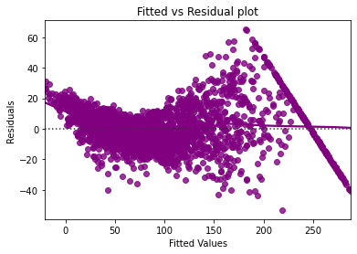

```python
# let's plot the fitted values vs residuals

sns.residplot(
    data=df_pred, x="Fitted Values", y="Residuals", color="purple", lowess=True
)
plt.xlabel("Fitted Values")
plt.ylabel("Residuals")
plt.title("Fitted vs Residual plot")
plt.show()
```

### TEST FOR NORMALITY

**Why the test?**

- Error terms, or residuals, should be normally distributed. If the error terms are not normally distributed, confidence intervals of the coefficient estimates may become too wide or narrow. Once confidence interval becomes unstable, it leads to difficulty in estimating coefficients based on minimization of least squares. Non-normality suggests that there are a few unusual data points that must be studied closely to make a better model.

**How to check normality?**

- The shape of the histogram of residuals can give an initial idea about the normality.
- It can also be checked via a Q-Q plot of residuals. If the residuals follow a normal distribution, they will make a straight line plot, otherwise not.
- Other tests to check for normality includes the Shapiro-Wilk test.
  - Null hypothesis: Residuals are normally distributed
  - Alternate hypothesis: Residuals are not normally distributed

**How to fix if this assumption is not followed?**

- We can apply transformations like log, exponential, arcsinh, etc. as per our data.

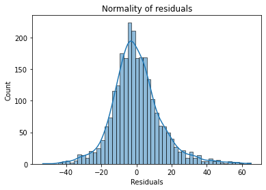

```python
# hist plot of residuals
sns.histplot(data=df_pred, x="Residuals", kde=True)
plt.title("Normality of residuals")
plt.show()
```

- The histogram of residuals does have a bell shape.
- Let's check the Q-Q plot.

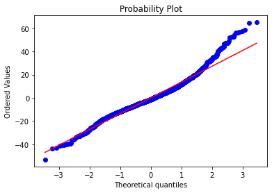

```python
# Q-Q plot
import pylab
import scipy.stats as stats

stats.probplot(df_pred["Residuals"], dist="norm", plot=pylab)
plt.show()
```

#### Observations:

- The residuals more or less follow a straight line except for the tails.
- Let's check the results of the Shapiro-Wilk test.

```python
# Shapiro-Wilk test
stats.shapiro(df_pred["Residuals"])
```

```
ShapiroResult(statistic=0.9676659107208252, pvalue=2.8181298532551635e-23)
```

### TEST FOR HOMOSCEDASTICITY

- **Homoscedascity**: If the variance of the residuals is symmetrically distributed across the regression line, then the data is said to be homoscedastic.
- **Heteroscedascity**: If the variance is unequal for the residuals across the regression line, then the data is said to be heteroscedastic.

**Why the test?**

- The presence of non-constant variance in the error terms results in heteroscedasticity. Generally, non-constant variance arises in presence of outliers.

**How to check for homoscedasticity?**

- The residual vs fitted values plot can be looked at to check for homoscedasticity. In the case of heteroscedasticity, the residuals can form an arrow shape or any other non-symmetrical shape.
- The goldfeldquandt test can also be used. If we get a p-value > 0.05 we can say that the residuals are homoscedastic. Otherwise, they are heteroscedastic.
  - Null hypothesis: Residuals are homoscedastic
  - Alternate hypothesis: Residuals have heteroscedasticity

**How to fix if this assumption is not followed?**

- Heteroscedasticity can be fixed by adding other important features or making transformations.

```python
import statsmodels.stats.api as sms
from statsmodels.compat import lzip

name = ["F statistic", "p-value"]
test = sms.het_goldfeldquandt(df_pred["Residuals"], x_train4)
lzip(name, test)
```

```
[('F statistic', 0.9482499852693774), ('p-value', 0.8243596687245189)]
```

**Since p-value > 0.05, we can say that the residuals are homoscedastic. So, this assumption is satisfied.**

```python
# predictions on the test set
pred = olsmod2.predict(x_test4)

df_pred_test = pd.DataFrame({"Actual": y_test, "Predicted": pred})
df_pred_test.sample(10, random_state=1)
```

|  | Actual | Predicted |
| --- | --- | --- |
| 255 | 194.45 | 171.245592 |
| 1398 | 170.24 | 149.577190 |
| 2253 | 164.76 | 206.690642 |
| 579 | 39.09 | 43.160815 |
| 3123 | 45.08 | 40.061247 |
| 1959 | 51.05 | 59.220330 |
| 3111 | 40.07 | 35.328094 |
| 1456 | 54.75 | 51.145557 |
| 3332 | 95.06 | 103.075903 |
| 855 | 44.03 | 46.711290 |

- We can observe here that our model has returned pretty good prediction results, and the actual and predicted values are comparable.
- We can also visualize comparison result as a bar graph.

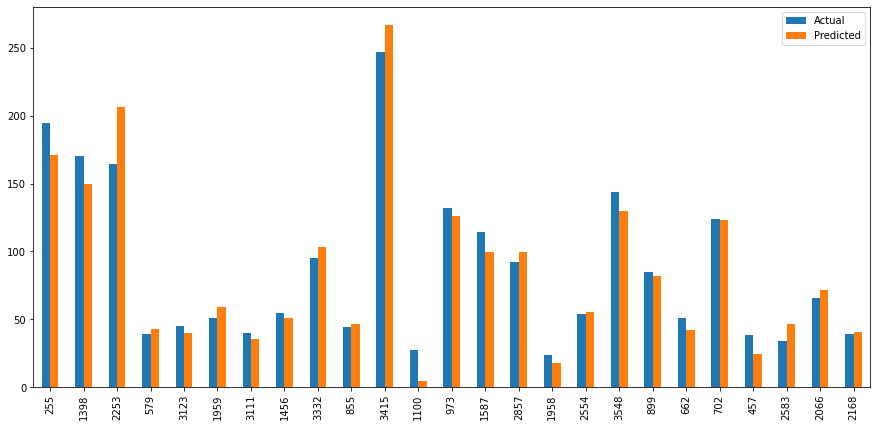

```python
# bar plot of predicted vs actual values.
df1 = df_pred_test.sample(25, random_state=1)
df1.plot(kind="bar", figsize=(15, 7))
plt.show()
```

```python
# checking model performance on train set (seen 70% data)
print("Training Performance\n")
olsmod2_train_perf = model_performance_regression(olsmod2, x_train4, y_train)
olsmod2_train_perf
```

```
Training Performance
```

|  | RMSE | MAE | R-squared | Adj. R-squared | MAPE |
| --- | --- | --- | --- | --- | --- |
| 0 | 13.841573 | 10.230734 | 0.956196 | 0.955878 | 18.120497 |

```python
# checking model performance on test set (seen 30% data)
print("Test Performance\n")
olsmod2_test_perf = model_performance_regression(olsmod2, x_test4, y_test)
olsmod2_test_perf
```

```
Test Performance
```

|  | RMSE | MAE | R-squared | Adj. R-squared | MAPE |
| --- | --- | --- | --- | --- | --- |
| 0 | 14.276996 | 10.340656 | 0.953406 | 0.952609 | 17.98171 |

- The model is able to explain ~95% of the variation in the data, which is very good.
- The train and test RMSE and MAE are low and comparable. So, our model is not suffering from overfitting.
- The MAPE on the test set suggests we can predict within 17.98% of the used price.
- Hence, we can conclude the model *olsmod2* is good for prediction as well as inference purposes.

**Let's compare the initial model created with sklearn and the final statsmodels model.**

## **7. Final Model Summary**

```python
# training performance comparison

models_train_comp_df = pd.concat(
    [ReCell_Sklearn_train_perf.T, olsmod2_train_perf.T],
    axis=1,
)

models_train_comp_df.columns = [
    "Linear Regression sklearn",
    "Linear Regression statsmodels",
]

print("Training performance comparison:")
models_train_comp_df
```

```
Training performance comparison:
```

|  | Linear Regression sklearn | Linear Regression statsmodels |
| --- | --- | --- |
| RMSE | 13.749809 | 13.841573 |
| MAE | 10.186292 | 10.230734 |
| R-squared | 0.956775 | 0.956196 |
| Adj. R-squared | 0.955946 | 0.955878 |
| MAPE | 18.037741 | 18.120497 |

```python
# test performance comparison

models_test_comp_df = pd.concat(
    [ReCell_Sklearn_test_perf.T, olsmod2_test_perf.T],
    axis=1,
)

models_test_comp_df.columns = [
    "Linear Regression sklearn",
    "Linear Regression statsmodels",
]

print("Test performance comparison:")
models_test_comp_df
```

```
Test performance comparison:
```

|  | Linear Regression sklearn | Linear Regression statsmodels |
| --- | --- | --- |
| RMSE | 14.539187 | 14.276996 |
| MAE | 10.530216 | 10.340656 |
| R-squared | 0.951679 | 0.953406 |
| Adj. R-squared | 0.949461 | 0.952609 |
| MAPE | 18.574210 | 17.981710 |

```python
olsmodel_final = sm.OLS(y_train, x_train4).fit()
print(olsmodel_final.summary())
```

```
                            OLS Regression Results
==============================================================================
Dep. Variable:             used_price   R-squared:                       0.956
Model:                            OLS   Adj. R-squared:                  0.956
Method:                 Least Squares   F-statistic:                     3186.
Date:                Sat, 23 Oct 2021   Prob (F-statistic):               0.00
Time:                        03:16:24   Log-Likelihood:                -10112.
No. Observations:                2499   AIC:                         2.026e+04
Df Residuals:                    2481   BIC:                         2.037e+04
Df Model:                          17
Covariance Type:            nonrobust
=========================================================================================
                            coef    std err          t      P>|t|      [0.025      0.975]
-----------------------------------------------------------------------------------------
const                    60.1604      1.995     30.161      0.000      56.249      64.072
screen_size               0.2582      0.086      3.016      0.003       0.090       0.426
main_camera_mp           -0.1602      0.067     -2.385      0.017      -0.292      -0.029
selfie_camera_mp          0.7005      0.087      8.052      0.000       0.530       0.871
int_memory                0.1006      0.010      9.994      0.000       0.081       0.120
days_used                -0.0842      0.002    -55.678      0.000      -0.087      -0.081
new_price                 0.3784      0.003    132.846      0.000       0.373       0.384
brand_name_BlackBerry    10.9322      3.566      3.066      0.002       3.940      17.925
brand_name_Gionee        -5.1664      2.227     -2.319      0.020      -9.534      -0.799
brand_name_Google        15.0490      4.663      3.227      0.001       5.904      24.194
brand_name_Infinix      -13.9285      5.033     -2.768      0.006     -23.797      -4.060
brand_name_Lenovo        -3.2891      1.320     -2.492      0.013      -5.877      -0.701
brand_name_Nokia         -7.4246      1.629     -4.557      0.000     -10.619      -4.230
brand_name_OnePlus      -12.5273      3.303     -3.792      0.000     -19.005      -6.049
os_Others                -4.0668      1.452     -2.800      0.005      -6.915      -1.219
os_iOS                   10.1426      2.341      4.333      0.000       5.553      14.732
4g_yes                   -3.2687      0.780     -4.190      0.000      -4.799      -1.739
5g_yes                    4.2321      1.624      2.606      0.009       1.048       7.416
==============================================================================
Omnibus:                      252.527   Durbin-Watson:                   1.977
Prob(Omnibus):                  0.000   Jarque-Bera (JB):              562.404
Skew:                           0.615   Prob(JB):                    7.51e-123
Kurtosis:                       4.972   Cond. No.                     1.36e+04
==============================================================================

Notes:
[1] Standard Errors assume that the covariance matrix of the errors is correctly specified.
[2] The condition number is large, 1.36e+04. This might indicate that there are
strong multicollinearity or other numerical problems.
```

## **8. Actionable Insights and Recommendations**

### Insights from the model

1. No of days used has a negative correlation to unit price; the less days the phone is used, higher the price tag on it.
2. The 5G phones have positive correlation and 4G phones have negative correlation. As 5G is an emerging feature, the phones with 5G capability can be sold at a higher used price.
3. The selfie camera has a positive correlation with used price and can be drive up the price of a used phone.
4. The phones with iOS operating system have a stable market price it has a positive correlation with used phone price.
5. The brands Blackberry and Google have positive correlation with Used price while brands OnePlus, Nokia and Infinix have negative correlation.

### Business Recommendations:

1. ReCell should give promotions to phones that are highly used. The more this phone sits in the store, it's value is going down day-by-day.
2. ReCell should try to increase the stock of 5G phones and the market is pointing towards that direction. Also have some deals on phones without 4G or 5G capability so that they can be sold easily.
3. ReCell can build an inventory of phones with high resolution selfie cameras.
4. ReCell can invest in procuring more phones with iOS operating system and their price does not go down with age.
5. ReCell can build an inventory of phones from the brands Blackberry and Google.